# SayenkoLabAssignmentAhish

## **Sayenko Lab (The Neuromodulation & Recovery Lab) Data Assignment**

https://sayenko.hmailabs.org/

**A. Problem statement**

The data includes responses across different vertebral stimulation levels, stimulation intensities (in mA), and recordings from eight muscles in three participants. The muscles are from the lower leg and include the rectus femoris (RF), medial hamstring (MH), soleus (SOL), and tibialis anterior (TA), recorded bilaterally (L = left, R = right). Please review the data and generate visualizations showing muscle responses at different stimulation sites. The y-axis should represent stimulation intensity. Use any software you're comfortable with (e.g., MATLAB, Python, or R). Be sure to include statistics and a figure legend.

This analysis explores peak EMG responses to spinal stimulation across three participants. The segmental activation patterns follow the principles described by Sayenko et al. (2024), where stimulation at specific vertebral levels preferentially activates lower limb reflexes

# **1. Installing necessary libraries**

```python
# Installing the libraries with the specified version.
!pip install numpy==1.25.2 pandas==1.5.3 matplotlib==3.7.1 seaborn==0.13.1 -q --user
!pip install openpyxl seaborn
```

[output not shown]

# **2. Importing necessary libraries**

Importing libraries and linking my google drive.

```python
# import libraries for data manipulation
import numpy as np
import pandas as pd

# import libraries for data visualization
import matplotlib.pyplot as plt
import seaborn as sns
```

```python
# let colab access my google drive
from google.colab import drive
drive.mount('/content/drive')
```

# **3.Loading the dataset**

Loading the given dataset which was downloaded and added to the google drive

```python
df = pd.read_excel('/content/drive/MyDrive/Python Course/EMG.xlsx')
```

```python
df
```

|  | Unnamed: 0 | Unnamed: 1 | Unnamed: 2 | Unnamed: 3 | Unnamed: 4 | Unnamed: 5 | Unnamed: 6 | Unnamed: 7 | Unnamed: 8 | Unnamed: 9 | ... | Unnamed: 19 | Unnamed: 20 | Unnamed: 21 | Unnamed: 22 | Unnamed: 23 | Unnamed: 24 | Unnamed: 25 | Unnamed: 26 | Unnamed: 27 | Unnamed: 28 |
| --- | --- | --- | --- | --- | --- | --- | --- | --- | --- | --- | --- | --- | --- | --- | --- | --- | --- | --- | --- | --- | --- |
| 0 | Location T11/12 | NaN | NaN | NaN | NaN | NaN | NaN | NaN | NaN | NaN | ... | NaN | Location T11/12 and L1/2 | NaN | NaN | NaN | NaN | NaN | NaN | NaN | NaN |
| 1 | mA | LRF | LMH | LTA | LSOL | RRF | RMH | RTA | RSOL | NaN | ... | NaN | mA | LRF | LMH | LTA | LSOL | RRF | RMH | RTA | RSOL |
| 2 | 40 | 0.009271 | 0.011042 | 0.018958 | 0.012292 | 0.0075 | 0.013229 | 0.012396 | 0.010104 | NaN | ... | NaN | 30 | 0.007396 | 0.009792 | 0.014792 | 0.007708 | 0.006979 | 0.009167 | 0.013333 | 0.009792 |
| 3 | 50 | 0.007812 | 0.010625 | 0.017396 | 0.012917 | 0.008229 | 0.009479 | 0.012083 | 0.010625 | NaN | ... | NaN | 40 | 0.008021 | 0.008854 | 0.011667 | 0.012604 | 0.008229 | 0.011146 | 0.01375 | 0.012604 |
| 4 | 60 | 0.008333 | 0.011771 | 0.021875 | 0.0125 | 0.007187 | 0.01125 | 0.012812 | 0.007917 | NaN | ... | NaN | 50 | 0.0075 | 0.009375 | 0.010312 | 0.010625 | 0.006875 | 0.009271 | 0.011979 | 0.009583 |
| 5 | 70 | 0.008646 | 0.008646 | 0.016354 | 0.009687 | 0.009687 | 0.009896 | 0.010417 | 0.009896 | NaN | ... | NaN | 60 | 0.009167 | 0.007708 | 0.01125 | 0.013854 | 0.007292 | 0.007396 | 0.017917 | 0.049375 |
| 6 | 80 | 0.007917 | 0.010104 | 0.023021 | 0.012083 | 0.009687 | 0.010104 | 0.012083 | 0.009271 | NaN | ... | NaN | 70 | 0.021875 | 0.076979 | 0.036875 | 0.090938 | 0.007917 | 0.012083 | 0.099479 | 0.340208 |
| 7 | 90 | 0.011979 | 0.009792 | 0.022396 | 0.013958 | 0.009271 | 0.009583 | 0.011979 | 0.00875 | NaN | ... | NaN | 80 | 0.176354 | 0.456042 | 0.068333 | 0.339896 | 0.021875 | 0.183438 | 0.175417 | 0.690104 |
| 8 | 100 | 0.022813 | 0.017187 | 0.022708 | 0.011146 | 0.013437 | 0.008438 | 0.012812 | 0.010938 | NaN | ... | NaN | 90 | 0.383333 | 0.707708 | 0.096354 | 0.417917 | 0.036979 | 0.547917 | 0.226562 | 0.936042 |
| 9 | 110 | 0.085625 | 0.142083 | 0.019167 | 0.011667 | 0.013854 | 0.012188 | 0.015833 | 0.009479 | NaN | ... | NaN | 100 | 0.480729 | 0.787292 | 0.097187 | 0.580521 | 0.125417 | 0.725938 | 0.340417 | 0.804479 |
| 10 | 120 | 0.189271 | 0.431667 | 0.029167 | 0.041875 | 0.016979 | 0.128958 | 0.022187 | 0.017708 | NaN | ... | NaN | 110 | 0.506354 | 0.865417 | 0.128854 | 0.587708 | 0.19375 | 0.818333 | 0.401146 | 0.818958 |
| 11 | 100 | 0.036563 | 0.0475 | 0.020938 | 0.011146 | 0.014167 | 0.009167 | 0.011042 | 0.009271 | NaN | ... | NaN | NaN | NaN | NaN | NaN | NaN | NaN | NaN | NaN | NaN |
| 12 | 110 | 0.107708 | 0.160729 | 0.018646 | 0.010833 | 0.014271 | 0.015937 | 0.015 | 0.010313 | NaN | ... | NaN | NaN | NaN | NaN | NaN | NaN | NaN | NaN | NaN | NaN |
| 13 | 120 | 0.192083 | 0.493021 | 0.041146 | 0.041667 | 0.014583 | 0.210625 | 0.025521 | 0.027292 | NaN | ... | NaN | NaN | NaN | NaN | NaN | NaN | NaN | NaN | NaN | NaN |
| 14 | 130 | 0.271979 | 0.638646 | 0.04375 | 0.056771 | 0.035833 | 0.438646 | 0.105729 | 0.114167 | NaN | ... | NaN | NaN | NaN | NaN | NaN | NaN | NaN | NaN | NaN | NaN |
| 15 | 140 | 0.361563 | 0.688229 | 0.108021 | 0.1025 | 0.060417 | 0.586875 | 0.166771 | 0.287083 | NaN | ... | NaN | NaN | NaN | NaN | NaN | NaN | NaN | NaN | NaN | NaN |
| 16 | 150 | 0.4525 | 0.756562 | 0.114375 | 0.249479 | 0.116354 | 0.742604 | 0.269062 | 0.492188 | NaN | ... | NaN | NaN | NaN | NaN | NaN | NaN | NaN | NaN | NaN | NaN |
| 17 | 160 | 0.470937 | 0.799583 | 0.126667 | 0.437604 | 0.177708 | 0.84625 | 0.315729 | 0.50875 | NaN | ... | NaN | NaN | NaN | NaN | NaN | NaN | NaN | NaN | NaN | NaN |
| 18 | 170 | 0.544167 | 0.825208 | 0.120937 | 0.551979 | 0.236354 | 0.922813 | 0.37 | 0.569896 | NaN | ... | NaN | NaN | NaN | NaN | NaN | NaN | NaN | NaN | NaN | NaN |
| 19 | 180 | 0.509479 | 0.840208 | 0.094792 | 0.399479 | 0.291979 | 0.982396 | 0.315833 | 0.486979 | NaN | ... | NaN | NaN | NaN | NaN | NaN | NaN | NaN | NaN | NaN | NaN |
| 20 | 190 | 0.569479 | 0.857187 | 0.1025 | 0.521563 | 0.340313 | 1.027604 | 0.400521 | 0.643854 | NaN | ... | NaN | NaN | NaN | NaN | NaN | NaN | NaN | NaN | NaN | NaN |

21 rows × 29 columns

# **4. Differentiating the 3 tables of just one participant**

```python
def extract_horizontal_tables(df, table_starts, table_width=9):
    tables = []
    for col_start in table_starts:
        table = df.iloc[1:, col_start:col_start + table_width].copy()
        table.columns = df.iloc[1, col_start:col_start + table_width].values
        table = table.dropna(how='all')  # remove empty rows
        tables.append(table.reset_index(drop=True))
    return tables

# Based on your layout: table starts at column 0, 10, 20
table_starts = [0, 10, 20]
tables = extract_horizontal_tables(df, table_starts)
```

```python
t11_12 = tables[0]
l1_2 = tables[1]
t11_l1 = tables[2]
```

Making sure all the tables are separated without any data lost.

```python
t11_12
```

|  | mA | LRF | LMH | LTA | LSOL | RRF | RMH | RTA | RSOL |
| --- | --- | --- | --- | --- | --- | --- | --- | --- | --- |
| 0 | mA | LRF | LMH | LTA | LSOL | RRF | RMH | RTA | RSOL |
| 1 | 40 | 0.009271 | 0.011042 | 0.018958 | 0.012292 | 0.0075 | 0.013229 | 0.012396 | 0.010104 |
| 2 | 50 | 0.007812 | 0.010625 | 0.017396 | 0.012917 | 0.008229 | 0.009479 | 0.012083 | 0.010625 |
| 3 | 60 | 0.008333 | 0.011771 | 0.021875 | 0.0125 | 0.007187 | 0.01125 | 0.012812 | 0.007917 |
| 4 | 70 | 0.008646 | 0.008646 | 0.016354 | 0.009687 | 0.009687 | 0.009896 | 0.010417 | 0.009896 |
| 5 | 80 | 0.007917 | 0.010104 | 0.023021 | 0.012083 | 0.009687 | 0.010104 | 0.012083 | 0.009271 |
| 6 | 90 | 0.011979 | 0.009792 | 0.022396 | 0.013958 | 0.009271 | 0.009583 | 0.011979 | 0.00875 |
| 7 | 100 | 0.022813 | 0.017187 | 0.022708 | 0.011146 | 0.013437 | 0.008438 | 0.012812 | 0.010938 |
| 8 | 110 | 0.085625 | 0.142083 | 0.019167 | 0.011667 | 0.013854 | 0.012188 | 0.015833 | 0.009479 |
| 9 | 120 | 0.189271 | 0.431667 | 0.029167 | 0.041875 | 0.016979 | 0.128958 | 0.022187 | 0.017708 |
| 10 | 100 | 0.036563 | 0.0475 | 0.020938 | 0.011146 | 0.014167 | 0.009167 | 0.011042 | 0.009271 |
| 11 | 110 | 0.107708 | 0.160729 | 0.018646 | 0.010833 | 0.014271 | 0.015937 | 0.015 | 0.010313 |
| 12 | 120 | 0.192083 | 0.493021 | 0.041146 | 0.041667 | 0.014583 | 0.210625 | 0.025521 | 0.027292 |
| 13 | 130 | 0.271979 | 0.638646 | 0.04375 | 0.056771 | 0.035833 | 0.438646 | 0.105729 | 0.114167 |
| 14 | 140 | 0.361563 | 0.688229 | 0.108021 | 0.1025 | 0.060417 | 0.586875 | 0.166771 | 0.287083 |
| 15 | 150 | 0.4525 | 0.756562 | 0.114375 | 0.249479 | 0.116354 | 0.742604 | 0.269062 | 0.492188 |
| 16 | 160 | 0.470937 | 0.799583 | 0.126667 | 0.437604 | 0.177708 | 0.84625 | 0.315729 | 0.50875 |
| 17 | 170 | 0.544167 | 0.825208 | 0.120937 | 0.551979 | 0.236354 | 0.922813 | 0.37 | 0.569896 |
| 18 | 180 | 0.509479 | 0.840208 | 0.094792 | 0.399479 | 0.291979 | 0.982396 | 0.315833 | 0.486979 |
| 19 | 190 | 0.569479 | 0.857187 | 0.1025 | 0.521563 | 0.340313 | 1.027604 | 0.400521 | 0.643854 |

```python
l1_2
```

|  | mA | LRF | LMH | LTA | LSOL | RRF | RMH | RTA | RSOL |
| --- | --- | --- | --- | --- | --- | --- | --- | --- | --- |
| 0 | mA | LRF | LMH | LTA | LSOL | RRF | RMH | RTA | RSOL |
| 1 | 30 | 0.015312 | 0.016667 | 0.013021 | 0.017083 | 0.024896 | 0.010938 | 0.013958 | 0.013854 |
| 2 | 40 | 0.025313 | 0.022396 | 0.012604 | 0.016979 | 0.033229 | 0.012187 | 0.022604 | 0.057188 |
| 3 | 50 | 0.031563 | 0.027292 | 0.043646 | 0.157292 | 0.046042 | 0.013125 | 0.136146 | 0.518125 |
| 4 | 60 | 0.122812 | 0.3575 | 0.059896 | 0.380937 | 0.056771 | 0.061771 | 0.199687 | 0.855833 |
| 5 | 70 | 0.404062 | 0.728229 | 0.098437 | 0.513333 | 0.064167 | 0.581458 | 0.229167 | 0.837708 |
| 6 | 80 | 0.513646 | 0.837604 | 0.12625 | 0.593854 | 0.146042 | 0.773438 | 0.326667 | 0.92125 |
| 7 | 90 | 0.585938 | 0.9125 | 0.154375 | 0.632917 | 0.256042 | 0.901563 | 0.433125 | 0.938542 |
| 8 | 100 | 0.612083 | 0.957604 | 0.178542 | 0.67875 | 0.376979 | 0.973854 | 0.479063 | 0.958542 |

```python
t11_l1
```

|  | mA | LRF | LMH | LTA | LSOL | RRF | RMH | RTA | RSOL |
| --- | --- | --- | --- | --- | --- | --- | --- | --- | --- |
| 0 | mA | LRF | LMH | LTA | LSOL | RRF | RMH | RTA | RSOL |
| 1 | 30 | 0.007396 | 0.009792 | 0.014792 | 0.007708 | 0.006979 | 0.009167 | 0.013333 | 0.009792 |
| 2 | 40 | 0.008021 | 0.008854 | 0.011667 | 0.012604 | 0.008229 | 0.011146 | 0.01375 | 0.012604 |
| 3 | 50 | 0.0075 | 0.009375 | 0.010312 | 0.010625 | 0.006875 | 0.009271 | 0.011979 | 0.009583 |
| 4 | 60 | 0.009167 | 0.007708 | 0.01125 | 0.013854 | 0.007292 | 0.007396 | 0.017917 | 0.049375 |
| 5 | 70 | 0.021875 | 0.076979 | 0.036875 | 0.090938 | 0.007917 | 0.012083 | 0.099479 | 0.340208 |
| 6 | 80 | 0.176354 | 0.456042 | 0.068333 | 0.339896 | 0.021875 | 0.183438 | 0.175417 | 0.690104 |
| 7 | 90 | 0.383333 | 0.707708 | 0.096354 | 0.417917 | 0.036979 | 0.547917 | 0.226562 | 0.936042 |
| 8 | 100 | 0.480729 | 0.787292 | 0.097187 | 0.580521 | 0.125417 | 0.725938 | 0.340417 | 0.804479 |
| 9 | 110 | 0.506354 | 0.865417 | 0.128854 | 0.587708 | 0.19375 | 0.818333 | 0.401146 | 0.818958 |

# **5. Missing value corrections and a sample plot**

```python
def label_table(df, site, participant):
    df = df.copy()
    df['Site'] = site
    df['Participant'] = participant
    return df

p1_df = pd.concat([
    label_table(t11_12, 'T11/12', 'P1'),
    label_table(l1_2, 'L1/2', 'P1'),
    label_table(t11_l1, 'T11/12 & L1/2', 'P1')
])
```

1. The Stimulation intensity (mA) column needs to be be coerced as it identifies as NaN- not a number.
2. A sample plot for just one of the tables. EMG response plot for Participant 1 at Left Rectus Femoris.

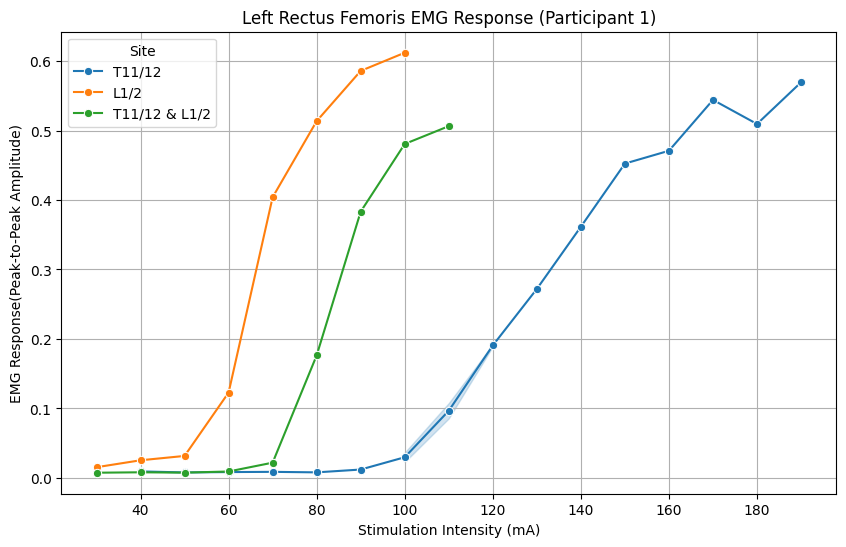

```python
# Clean 'mA' column: convert to numeric, coerce errors to NaN, then drop NaNs
p1_df['mA'] = pd.to_numeric(p1_df['mA'], errors='coerce')
p1_df = p1_df.dropna(subset=['mA'])

# Plot EMG response for Left Rectus Femoris
plt.figure(figsize=(10, 6))
sns.lineplot(data=p1_df, x='mA', y='LRF', hue='Site', marker='o')
plt.title('Left Rectus Femoris EMG Response (Participant 1)')
plt.xlabel('Stimulation Intensity (mA)')
plt.ylabel('EMG Response(Peak-to-Peak Amplitude)')
plt.grid(True)
plt.show()
```

# **6. EMG response vs Stimulation intensity at various stimulation sites of 3 different participants.**

This code reads EMG data for multiple participants from the Excel file, organizes it by stimulation site and participant, cleans it by filtering non-numeric stimulation intensities, and combines all into a single DataFrame. It then plots the EMG response of each muscle as a line graph against stimulation intensity, with lines distinguished by site and participant.

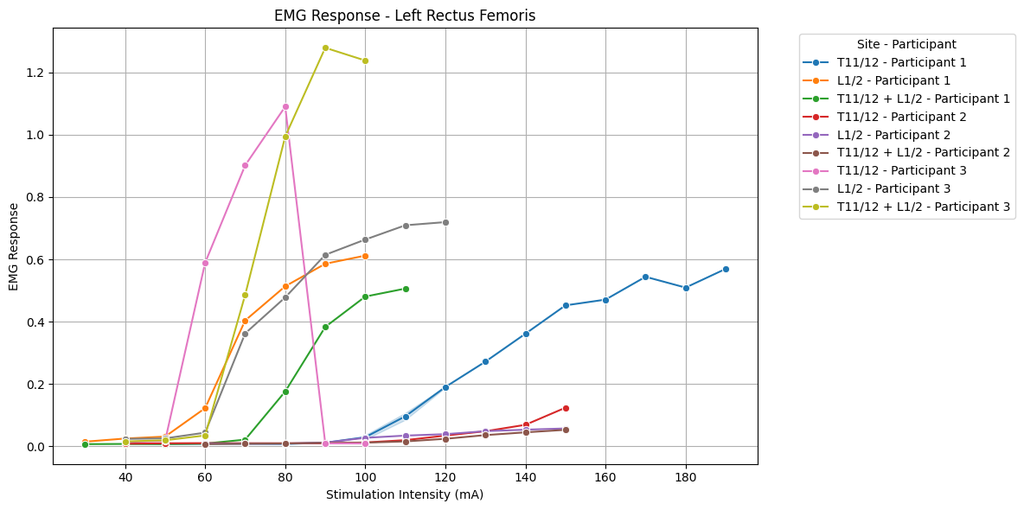

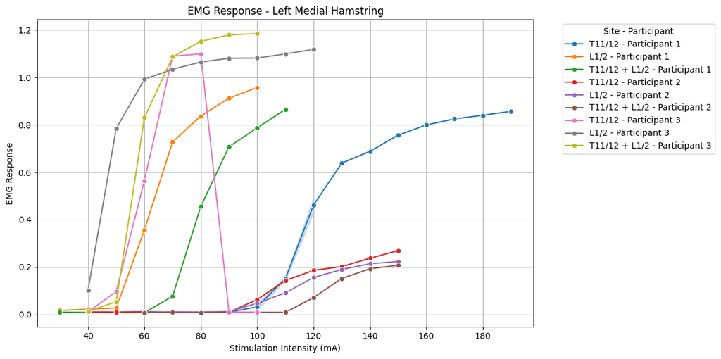

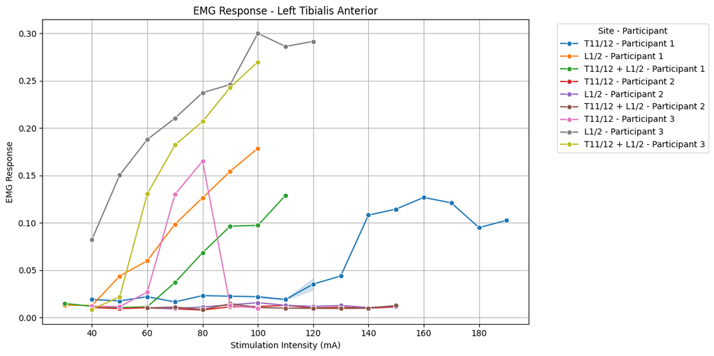

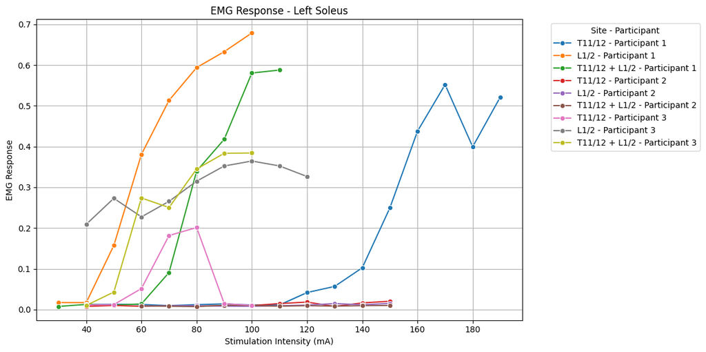

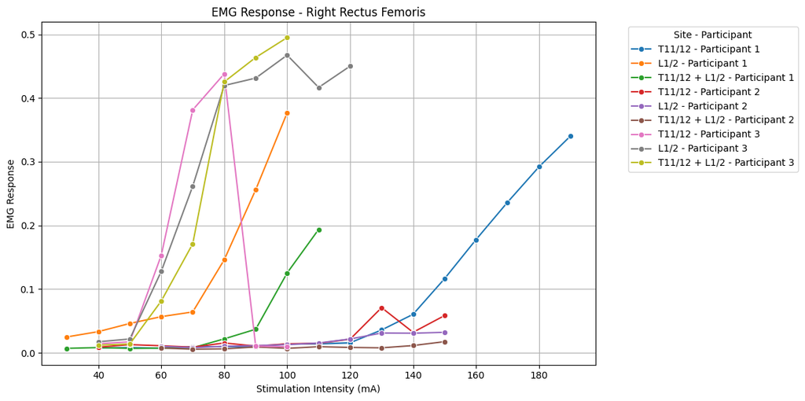

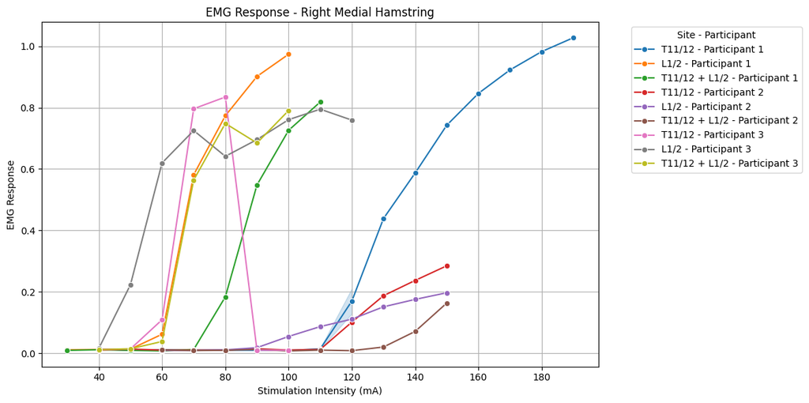

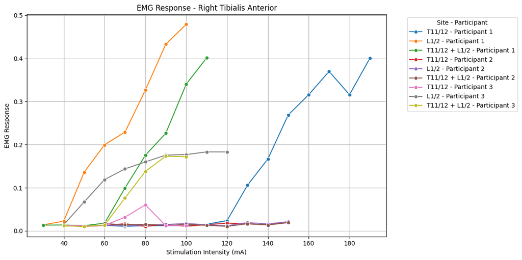

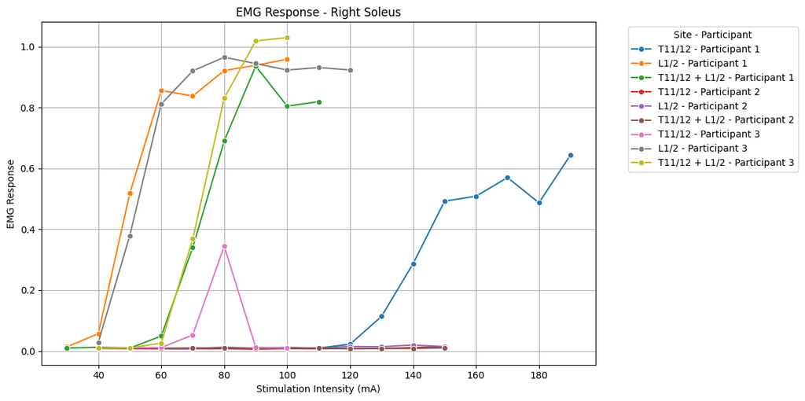

```python
# Loading the same file from drive
file_path = '/content/drive/MyDrive/Python Course/EMG.xlsx'
# Define muscle labels
muscles = ['Left Rectus Femoris', 'Left Medial Hamstring', 'Left Tibialis Anterior', 'Left Soleus',
           'Right Rectus Femoris', 'Right Medial Hamstring', 'Right Tibialis Anterior', 'Right Soleus']

# Define stimulation sites and their corresponding column positions
site_names = ['T11/12', 'L1/2', 'T11/12 + L1/2']
site_starts = [0, 10, 20]  # Starting column index of each site data

# Store all cleaned data
all_data = []

# Process each participant sheet
for sheet_name in ['Participant 1', 'Participant 2', 'Participant 3']:
    df = pd.read_excel(file_path, sheet_name=sheet_name, header=None)

    for i, start_col in enumerate(site_starts):
        # Slice the sub-table
        sub_df = df.iloc[2:, start_col:start_col + 9].copy()
        sub_df.columns = ['mA'] + muscles

        # Drop rows where mA is not numeric
        sub_df['mA'] = pd.to_numeric(sub_df['mA'], errors='coerce')
        sub_df = sub_df.dropna(subset=['mA'])

        # Add site and participant labels
        sub_df['Site'] = site_names[i]
        sub_df['Participant'] = sheet_name

        # Append to overall list
        all_data.append(sub_df)

# Combine all participant data
combined_df = pd.concat(all_data, ignore_index=True)

# Create a combined label for unique hue
combined_df['Site_Participant'] = combined_df['Site'] + ' - ' + combined_df['Participant']

# Plot 8 muscle responses separately
for muscle in muscles:
    plt.figure(figsize=(12, 6))
    sns.lineplot(
        data=combined_df,
        x='mA',
        y=muscle,
        hue='Site_Participant',
        marker='o'
    )
    plt.title(f'EMG Response - {muscle}')
    plt.xlabel('Stimulation Intensity (mA)')
    plt.ylabel('EMG Response')
    plt.grid(True)
    plt.legend(title='Site - Participant', bbox_to_anchor=(1.05, 1), loc='upper left')
    plt.tight_layout()
    plt.show()
```

# **7. Heatmaps per Participant per Site for comparing muscle responses spatially**

The heatmap shows how strongly each leg muscle responded to spinal cord stimulation at different intensities. Lighter colors mean stronger muscle responses, while darker areas indicate weaker or no response. This helps us see which muscles are most active at specific spinal levels and stimulation strengths for each person.

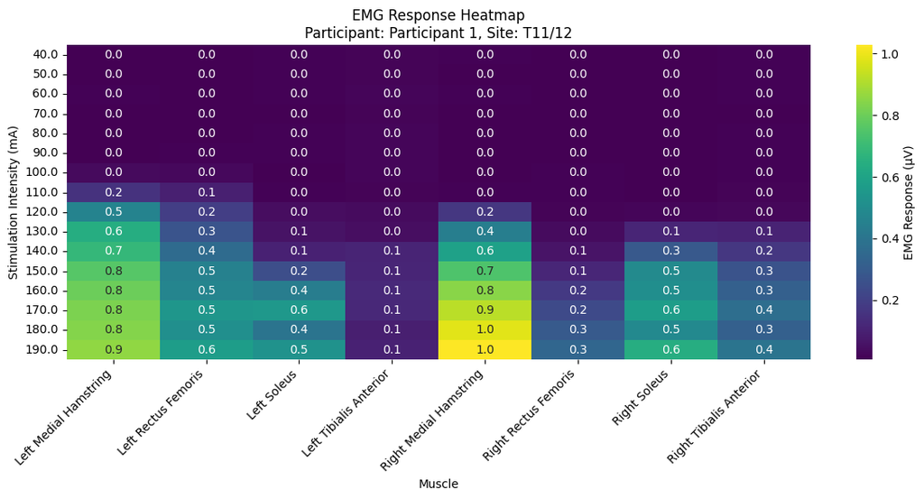

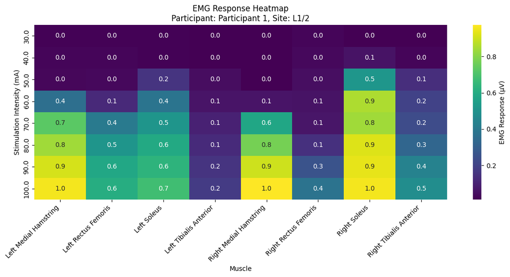

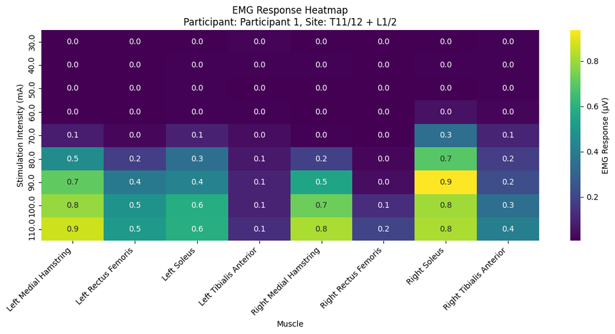

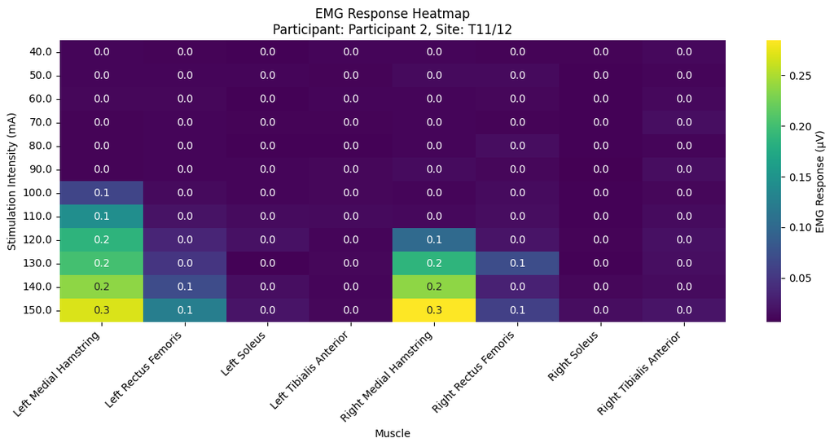

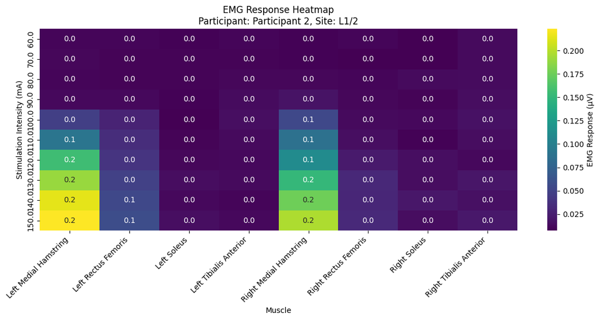

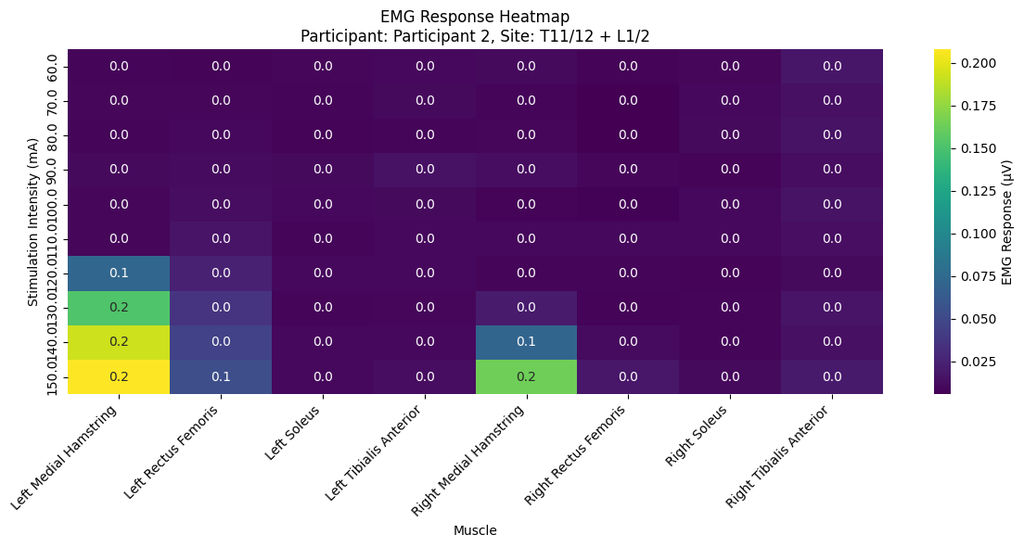

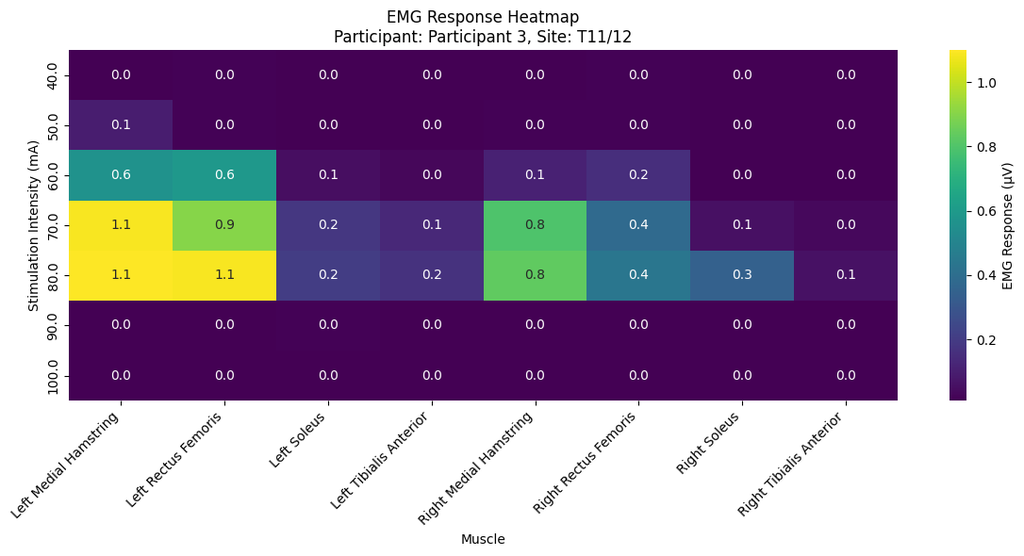

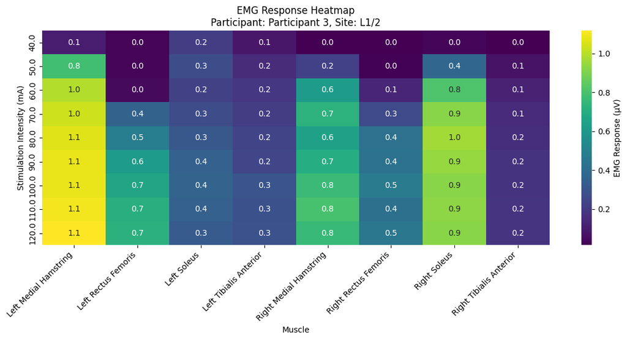

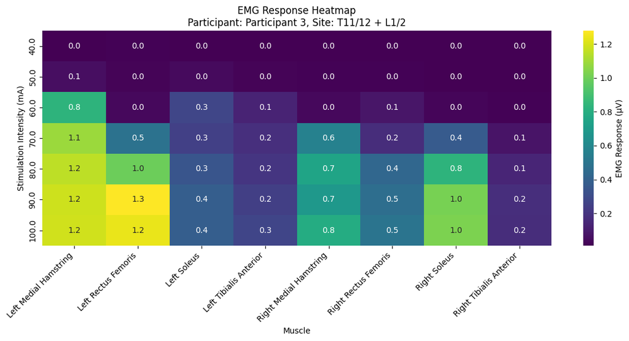

```python
import matplotlib.pyplot as plt
import seaborn as sns
import pandas as pd

# Define participants, muscles, and stimulation sites
participants = ['Participant 1', 'Participant 2', 'Participant 3']
stim_sites = combined_df['Site'].unique()
muscles = ['Left Rectus Femoris', 'Left Medial Hamstring', 'Left Tibialis Anterior', 'Left Soleus',
           'Right Rectus Femoris', 'Right Medial Hamstring', 'Right Tibialis Anterior', 'Right Soleus']

for participant in participants:
    for site in stim_sites:
        # Filter data
        subset = combined_df[(combined_df['Participant'] == participant) &
                             (combined_df['Site'] == site)]

        if not subset.empty:
            # Melt and pivot
            melted = subset.melt(id_vars=['mA'], value_vars=muscles,
                                 var_name='Muscle', value_name='Response')
            heatmap_data = melted.pivot_table(index='mA', columns='Muscle', values='Response')
            heatmap_data = heatmap_data.astype(float).fillna(0)  # fix: convert to float and fill missing

            # Plot
            plt.figure(figsize=(12, 6))
            sns.heatmap(heatmap_data, cmap="viridis", annot=True, fmt=".1f",
                        cbar_kws={'label': 'EMG Response (μV)'})
            plt.title(f'EMG Response Heatmap\nParticipant: {participant}, Site: {site}')
            plt.ylabel('Stimulation Intensity (mA)')
            plt.xlabel('Muscle')
            plt.xticks(rotation=45, ha='right')
            plt.tight_layout()
            plt.show()
        else:
            print(f"No data for Participant {participant} at Site {site}")
```

# **8. Correlation analysis: See if response magnitude increases with Stimulation intensity**

```python
# Calculate correlation between 'mA' and each muscle's EMG response
correlation_result = {} # Initialize a dictionary to store correlation results
for muscle in muscles:
    correlation = combined_df['mA'].corr(combined_df[muscle])
    correlation_result[muscle] = correlation # Store correlation for each muscle
correlation_table = pd.DataFrame(correlation_result, index=['Correlation']).T #index=['Correlation'] sets 'Correlation' as the index, .T transposes
correlation_table
```

|  | Correlation |
| --- | --- |
| Left Rectus Femoris | 0.232180 |
| Left Medial Hamstring | 0.267208 |
| Left Tibialis Anterior | 0.098726 |
| Left Soleus | 0.199285 |
| Right Rectus Femoris | 0.205730 |
| Right Medial Hamstring | 0.413598 |
| Right Tibialis Anterior | 0.346562 |
| Right Soleus | 0.118262 |

# **9. The average emg response for all 3 participants at a particular stimulation site.**

This bar plot compares the average EMG response of each leg muscle between the three participants at a specific spinal stimulation site(t11-12). Each group of bars shows how strongly that muscle responded in each person, helping identify differences in activation patterns. It gives a quick visual summary of how effective the stimulation was for each muscle across individuals.

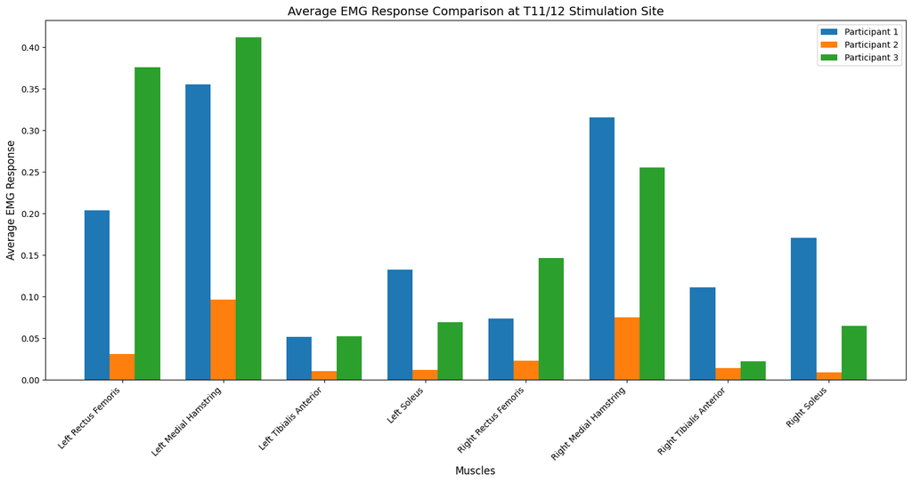

```python
def plot_average_emg_comparison(combined_df, stim_site):
    """
    Generates average EMG response for participant 1 at a particular muscle,
    compares it with participant 2 and 3, and creates a bar plot for all muscles.

    Args:
        combined_df: DataFrame containing EMG data.
        stim_site: The stimulation site to analyze.
    """

    participants = ['Participant 1', 'Participant 2', 'Participant 3']
    muscles = ['Left Rectus Femoris', 'Left Medial Hamstring', 'Left Tibialis Anterior', 'Left Soleus',
               'Right Rectus Femoris', 'Right Medial Hamstring', 'Right Tibialis Anterior', 'Right Soleus']

    average_emg = {}
    for participant in participants:
        average_emg[participant] = {}
        for muscle in muscles:
            participant_data = combined_df[(combined_df['Participant'] == participant) &
                                            (combined_df['Site'] == stim_site)]
            average_emg[participant][muscle] = participant_data[muscle].mean() if not participant_data.empty else 0


    #Creating the bar plot
    plt.figure(figsize=(15, 8))
    bar_width = 0.25
    index = np.arange(len(muscles))

    for i, participant in enumerate(participants):
        plt.bar(index + i * bar_width, average_emg[participant].values(), bar_width, label=participant)

    plt.xlabel("Muscles", fontsize=12)
    plt.ylabel("Average EMG Response", fontsize=12)
    plt.title(f"Average EMG Response Comparison at {stim_site} Stimulation Site", fontsize=14)
    plt.xticks(index + bar_width, muscles, rotation=45, ha="right", fontsize=10)
    plt.legend()
    plt.tight_layout()
    plt.show()

# Example usage (replace with any desired stimulation site)
plot_average_emg_comparison(combined_df, "T11/12")
```

# **11. Summary**

The analysis presented here aligns with previous findings on spinal cord neuromodulation. The segmental specificity of EMG responses observed across stimulation sites (T11/12, L1/2, and combined) reflects well-established principles of spinal network organization. Steele et al. (2025) demonstrated that epidural stimulation in porcine models can selectively activate proximal or distal hindlimb muscles depending on the rostrocaudal electrode location, offering a map of functional sensorimotor organization that closely mirrors our human data trends. Similarly, the transcutaneous stimulation approach described by Gerasimenko et al. (2015) confirmed that stimulation at more rostral sites preferentially recruits proximal motor pools (e.g., rectus femoris), while caudal sites engage distal muscles (e.g., soleus, tibialis anterior). Our findings — especially the increase in peak-to-peak EMG amplitudes with stimulation intensity and site-dependent response profiles — are consistent with this topographical gradient of motor recruitment. This underscores the translational relevance of segment-specific spinal stimulation in both clinical and experimental applications.